# PS106.2 Shelf break study - Acoustic analyses

Pierre Priou

11/23/2020

## Methods

### Sampling and processing of hydroacoustic data

Acoustic data scrutinized, cleaned, and edited using Echoview 11 (Echoview Software Pty Ltd.). We removed background (minimum 10 dB signal-to-noise ratio) and impulse noise with Echoview’s algorithms. We excluded data in the transducers dead zone (20 m depth) and within 5 m of the seafloor. Acoustic backscatter was echo-integrated in 10 min long x 5 m deep cells from which the mean volume backscattering strength (MVBS in dB re 1 m<sup>-1</sup>) and nautical area scattering coefficient (s<sub>A</sub> in m<sup>2</sup> nmi<sup>-2</sup>) were exported for each cell and analyzed in R (version 4.0.3, R Core Team).

## Results

To this date, I have only processed data from June 30, 2017 during which the RV *Polarstern* crossed the shelf break North East of Svalbard.

### Vertical distribution of scatterers

The scatterers were distributed in two main sound scattering features, a shallow sound scattering layer (SSL) between 0 and 150 m depth in the epipelagic zone (Figure 1a, b), and a deep scattering layer (DSL) between ~ 280 and 630 m depth in the mesopelagic zone (Figure 1c, d ,e). The SSL was present over the shelf, slope, and deep basin whereas was associated with the slope and extended into the deep basin.

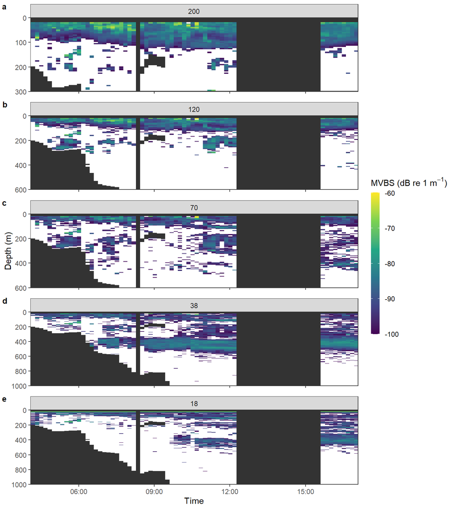

Figure 1. Echogram of mean volume backscattering strength (MVBS) over the shelf break North East of Svalbard on June 30, 2017 at 200 (**a**), 120 (**b**), 70 (**c**), 38 (**d**), 18 (**e**) kHz. **Note the different depth axis**. Areas with bad acoustic data (due to acoustic interference with other instruments, or breaking sea-ice, or dead zone near the surface) are black.